# Self-Driving Car Engineer Nanodegree

### Question 3

*What does your final architecture look like? (Type of model, layers, sizes, connectivity, etc.) For reference on how to build a deep neural network using TensorFlow, see Deep Neural Network in TensorFlow from the classroom.*

**Answer:**

first,i use a simple linear regression structure whichi yield not good accurate. then i choose a lenet model ,it turns better. and finaly i choose a modified lenet model,whichi shows a satisfied result.

```
# Hyperparameters
mu = 0
sigma = 0.1

# SOLUTION: Layer 1: Convolutional. Input = 32x32x1. Output = 28x28x16.
conv1_W = tf.Variable(tf.truncated_normal(shape=(5, 5, 1, 16), mean = mu, stddev = sigma))
conv1_b = tf.Variable(tf.zeros(16))
conv1   = tf.nn.conv2d(x, conv1_W, strides=[1, 1, 1, 1], padding='VALID') + conv1_b

# SOLUTION: Activation.
conv1 = tf.nn.relu(conv1)

# SOLUTION: Pooling. Input = 28x28x16. Output = 14x14x16.
conv1 = tf.nn.max_pool(conv1, ksize=[1, 2, 2, 1], strides=[1, 2, 2, 1], padding='VALID')

# SOLUTION: Layer 2: Convolutional. Output = 10x10x32.
conv2_W = tf.Variable(tf.truncated_normal(shape=(5, 5, 16, 32), mean = mu, stddev = sigma))
conv2_b = tf.Variable(tf.zeros(32))
conv2   = tf.nn.conv2d(conv1, conv2_W, strides=[1, 1, 1, 1], padding='VALID') + conv2_b

# SOLUTION: Activation.
conv2 = tf.nn.relu(conv2)

# SOLUTION: Pooling. Input = 10x10x32. Output = 5x5x32.
conv2 = tf.nn.max_pool(conv2, ksize=[1, 2, 2, 1], strides=[1, 2, 2, 1], padding='VALID')

# SOLUTION: Flatten. Input = 5x5x32. Output = 800.
fc0   = flatten(conv2)

# SOLUTION: Layer 3: Fully Connected. Input = 800. Output = 256.
fc1_W = tf.Variable(tf.truncated_normal(shape=(800, 256), mean = mu, stddev = sigma))
fc1_b = tf.Variable(tf.zeros(256))
fc1   = tf.matmul(fc0, fc1_W) + fc1_b

# SOLUTION: Activation.
fc1    = tf.nn.relu(fc1)

# SOLUTION: Layer 4: Fully Connected. Input = 256. Output = 128.
fc2_W  = tf.Variable(tf.truncated_normal(shape=(256, 128), mean = mu, stddev = sigma))
fc2_b  = tf.Variable(tf.zeros(128))
fc2    = tf.matmul(fc1, fc2_W) + fc2_b

# SOLUTION: Activation.
fc2    = tf.nn.relu(fc2)

# SOLUTION: Layer 5: Fully Connected. Input = 128. Output =  n_classes,in this case equals 43
fc3_W  = tf.Variable(tf.truncated_normal(shape=(128,  n_classes), mean = mu, stddev = sigma))
fc3_b  = tf.Variable(tf.zeros( n_classes))
logits = tf.matmul(fc2, fc3_W) + fc3_b

return logits
```

### Question 4

*How did you train your model? (Type of optimizer, batch size, epochs, hyperparameters, etc.)*

### Question 5

*What approach did you take in coming up with a solution to this problem? It may have been a process of trial and error, in which case, outline the steps you took to get to the final solution and why you chose those steps. Perhaps your solution involved an already well known implementation or architecture. In this case, discuss why you think this is suitable for the current problem.*

## Step 3: Test a Model on New Images

Take several pictures of traffic signs that you find on the web or around you (at least five), and run them through your classifier on your computer to produce example results. The classifier might not recognize some local signs but it could prove interesting nonetheless.

You may find `signnames.csv` useful as it contains mappings from the class id (integer) to the actual sign name.

### Implementation

Use the code cell (or multiple code cells, if necessary) to implement the first step of your project. Once you have completed your implementation and are satisfied with the results, be sure to thoroughly answer the questions that follow.

```python
import os
import matplotlib.pyplot as plt
import matplotlib.image as mpimg
%matplotlib inline
file_path="./download signs/"
file_list=os.listdir(file_path)
print(file_list)
web_images=[]
web_labels=[1,13,14,15,17,18,21,26,27,31,35]
for i in range(len(file_list)):
    image = mpimg.imread(file_path+file_list[i])
    image=cv2.resize(image, (32, 32))
    web_images.append(image)
web_images=np.array(web_images)
web_images_gray=np.array(rgb2gray(web_images),dtype=np.float32).reshape((len(web_images),32,32,1))
web_images_gray_normal=image_normalizing(web_images_gray)
#web_labels=np.array(web_labels).astype(int)

with tf.Session() as sess:
    #sess.run(tf.initialize_all_variables())
    #ckpt = tf.train.get_checkpoint_state("./")
    #if ckpt and ckpt.model_checkpoint_path:
        #print("Continue training from the model {}".format(ckpt.model_checkpoint_path))
        #print(saver)
        #print(saver.restore(sess, ckpt.model_checkpoint_path))
    #ckpt = tf.train.import_meta_graph('model.ckpt.meta')
    #ckpt.restore(sess, './model.ckpt')
    print(saver.restore(sess,save_file))
    web_images_test_accuracy = evaluate(web_images_gray_normal, web_labels)
    print("Test Accuracy = {:.3f}".format(test_accuracy))
```

```
['1.jpg', '13.jpg', '14.jpg', '15.jpg', '17.jpg', '18.jpg', '21.jpg', '26.jpg', '27.jpg', '31.jpg', '35.jpg']
None
Test Accuracy = 0.943
```

### Question 6

*Choose five candidate images of traffic signs and provide them in the report. Are there any particular qualities of the image(s) that might make classification difficult? It could be helpful to plot the images in the notebook.*

```python
### Run the predictions here.
### Feel free to use as many code cells as needed.
import os
import matplotlib.pyplot as plt
import matplotlib.image as mpimg
%matplotlib inline

"""
def evaluation(logits, labels):
    Evaluate the quality of the logits at predicting the label.

  Args:
    logits: Logits tensor, float - [batch_size, NUM_CLASSES].
    labels: Labels tensor, int32 - [batch_size], with values in the
      range [0, NUM_CLASSES).

  Returns:
    A scalar int32 tensor with the number of examples (out of batch_size)
    that were predicted correctly.

  # For a classifier model, we can use the in_top_k Op.
  # It returns a bool tensor with shape [batch_size] that is true for
  # the examples where the label's is was in the top k (here k=1)
  # of all logits for that example.
  correct = tf.nn.in_top_k(logits, labels, 1)
  # Return the number of true entries.
  return tf.reduce_sum(tf.cast(correct, tf.int32))
"""
file_path="./download signs/"
file_list=os.listdir(file_path)
print(file_list)
web_images=[]
web_labels=[1,13,14,15,17,18,21,26,27,31,35]
for i in range(len(file_list)):
    image = mpimg.imread(file_path+file_list[i])
    image=cv2.resize(image, (32, 32))
    web_images.append(image)
web_images=np.array(web_images)
web_images_gray=np.array(rgb2gray(web_images),dtype=np.float32).reshape((len(web_images),32,32,1))
web_images_gray_normal=image_normalizing(web_images_gray)


x = tf.placeholder(tf.float32, (None, 32, 32,1))
y = tf.placeholder(tf.int32, (None))
logits = LeNetModify1(web_images_gray_normal)
probability = tf.nn.softmax(logits)
prediction=tf.argmax(probability,axis=1)

topFive=tf.nn.top_k(probability, k=5, sorted=True, name=None)
top_k_feed_dict = {x: web_images_gray_normal}

correct_predictions = tf.equal(prediction, web_labels)
accuracy = tf.reduce_mean(tf.cast(correct_predictions, tf.float32))

save_file=".\model.ckpt"
#saver = tf.train.Saver()

with tf.Session() as sess:
    sess.run(tf.initialize_all_variables())
    ckpt = tf.train.get_checkpoint_state("./")
    if ckpt and ckpt.model_checkpoint_path:
        print("Continue training from the model {}".format(ckpt.model_checkpoint_path))
        #print(saver)
        #print(saver.restore(sess, ckpt.model_checkpoint_path))
    ckpt = tf.train.import_meta_graph('model.ckpt.meta')
    ckpt.restore(sess, './model.ckpt')
    #print(saver.restore(sess,save_file))
    print("web image labels are",web_labels)
    print("predictions are",sess.run(prediction))
    print(" probabilities are",sess.run(probability))
    print("accuracy of precition is ",accuracy.eval())
    print(sess.run(topFive, feed_dict = top_k_feed_dict))
```

[output not shown]

[output cut: 62 more lines]

```
       [ 0.084068  ,  0.08381926,  0.06186154,  0.0531331 ,  0.04794854],
       [ 0.12507397,  0.09754763,  0.08743095,  0.07103639,  0.0539696 ],
       [ 0.16740255,  0.06804247,  0.06743129,  0.05297595,  0.05003201],
       [ 0.09263918,  0.05229193,  0.05094524,  0.04782945,  0.03815796],
       [ 0.0827319 ,  0.07787395,  0.0594427 ,  0.05584914,  0.04822228]], dtype=float32), indices=array([[18, 29, 31, 39, 15],
       [29, 25, 18, 31, 15],
       [39, 25, 18, 12, 29],
       [29, 39, 38,  7, 22],
       [29,  7, 31, 18, 39],
       [29,  7, 15, 25, 31],
       [ 7, 29, 30, 39, 18],
       [29,  7, 15, 25, 30],
       [29, 22,  7, 39, 18],
       [31, 29,  7, 39, 12],
       [29, 31, 12, 39, 38]]))
```

[figure not shown]

[figure not shown]

[figure not shown]

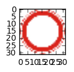

[figure not shown]

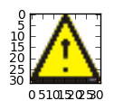

[figure not shown]

[figure not shown]

[figure not shown]

[figure not shown]

[figure not shown]

```python
for i in range(len(web_images)):
    image = web_images[i].squeeze()
    plt.figure(figsize=(1,1))
    plt.imshow(image)
```

[output not shown]

### Question 7

*Is your model able to perform equally well on captured pictures when compared to testing on the dataset? The simplest way to do this check the accuracy of the predictions. For example, if the model predicted 1 out of 5 signs correctly, it's 20% accurate.*

**NOTE:** You could check the accuracy manually by using `signnames.csv` (same directory). This file has a mapping from the class id (0-42) to the corresponding sign name. So, you could take the class id the model outputs, lookup the name in `signnames.csv` and see if it matches the sign from the image.

### Question 8

*Use the model's softmax probabilities to visualize the **certainty** of its predictions, [`tf.nn.top_k`](https://www.tensorflow.org/versions/r0.12/api_docs/python/nn.html#top_k) could prove helpful here. Which predictions is the model certain of? Uncertain? If the model was incorrect in its initial prediction, does the correct prediction appear in the top k? (k should be 5 at most)*

`tf.nn.top_k` will return the values and indices (class ids) of the top k predictions. So if k=3, for each sign, it'll return the 3 largest probabilities (out of a possible 43) and the correspoding class ids.

Take this numpy array as an example:

```
# (5, 6) array
a = np.array([[ 0.24879643,  0.07032244,  0.12641572,  0.34763842,  0.07893497,
         0.12789202],
       [ 0.28086119,  0.27569815,  0.08594638,  0.0178669 ,  0.18063401,
         0.15899337],
       [ 0.26076848,  0.23664738,  0.08020603,  0.07001922,  0.1134371 ,
         0.23892179],
       [ 0.11943333,  0.29198961,  0.02605103,  0.26234032,  0.1351348 ,
         0.16505091],
       [ 0.09561176,  0.34396535,  0.0643941 ,  0.16240774,  0.24206137,
         0.09155967]])
```

Running it through `sess.run(tf.nn.top_k(tf.constant(a), k=3))` produces:

```
TopKV2(values=array([[ 0.34763842,  0.24879643,  0.12789202],
       [ 0.28086119,  0.27569815,  0.18063401],
       [ 0.26076848,  0.23892179,  0.23664738],
       [ 0.29198961,  0.26234032,  0.16505091],
       [ 0.34396535,  0.24206137,  0.16240774]]), indices=array([[3, 0, 5],
       [0, 1, 4],
       [0, 5, 1],
       [1, 3, 5],
       [1, 4, 3]], dtype=int32))
```

Looking just at the first row we get `[ 0.34763842, 0.24879643, 0.12789202]`, you can confirm these are the 3 largest probabilities in `a`. You'll also notice `[3, 0, 5]` are the corresponding indices.

```python
x = tf.placeholder(tf.float32, (None, 32, 32,1))
y = tf.placeholder(tf.int32, (None))
logits = LeNetModify1(web_images_gray_normal)
prediction = tf.nn.softmax(logits)
topFive=tf.nn.top_k(prediction, k=5, sorted=True, name=None)
top_k_feed_dict = {x: web_images_gray_normal}

init_op = tf.initialize_all_variables()


save_file=".\model.ckpt"
#saver = tf.train.Saver()
with tf.Session() as sess:
    sess.run(init_op)
    top_k_probabilities = sess.run(topFive, feed_dict=top_k_feed_dict)
    print(top_k_probabilities)
    values = np.array([top_k_probabilities.values])
    indices = np.array([top_k_probabilities.indices])
    #sess.run(tf.initialize_all_variables())
    ckpt = tf.train.get_checkpoint_state("./")
    if ckpt and ckpt.model_checkpoint_path:
        print("Continue training from the model {}".format(ckpt.model_checkpoint_path))
        #print(saver)
        #print(saver.restore(sess, ckpt.model_checkpoint_path))
    ckpt = tf.train.import_meta_graph('model.ckpt.meta')
    ckpt.restore(sess, './model.ckpt')
    #print(save_file)
    #print(saver.restore(sess,save_file))
    print(sess.run(topFive, feed_dict = top_k_feed_dict))
    #sess.run(evaluation(logits,web_labels))
    #web_images_test_accuracy = evaluate(web_images_gray_normal, web_labels)
    #print("Test Accuracy = {:.3f}".format(test_accuracy))
    #print(session.run(y_pred,feed_dict = {x: web_images_gray_normal}))
```

```
WARNING:tensorflow:From <ipython-input-19-deb1afa8e501>:9 in <module>.: initialize_all_variables (from tensorflow.python.ops.variables) is deprecated and will be removed after 2017-03-02.
Instructions for updating:
Use `tf.global_variables_initializer` instead.
TopKV2(values=array([[ 0.28507429,  0.06884204,  0.05951475,  0.05602842,  0.04012862],
       [ 0.18350342,  0.0985667 ,  0.07588598,  0.06097144,  0.04414776],
       [ 0.21701965,  0.09165222,  0.05466859,  0.05087453,  0.040593  ],
       [ 0.15066741,  0.06781102,  0.05338572,  0.04906429,  0.04711688],
       [ 0.10862678,  0.07376833,  0.06412438,  0.05917989,  0.05773789],
       [ 0.19889711,  0.14263745,  0.11174174,  0.06229178,  0.05054193],
       [ 0.14879502,  0.08585267,  0.0744562 ,  0.07265954,  0.05431537],
       [ 0.16112205,  0.09692021,  0.07380766,  0.06559175,  0.05714148],
       [ 0.21704572,  0.06588832,  0.06215843,  0.06020235,  0.05984039],
       [ 0.07701658,  0.05651635,  0.04593945,  0.04362527,  0.04144436],
       [ 0.17343099,  0.07774289,  0.06232468,  0.06220559,  0.05300493]], dtype=float32), indices=array([[28, 29, 22, 31, 38],
       [28, 38, 29, 31, 22],
       [28, 31, 22, 38, 12],
       [28, 31, 29, 35, 22],
       [28, 12, 37, 31, 22],
       [28, 22, 31, 29,  4],
       [28, 29, 31, 22,  4],
       [28, 31, 22, 38,  4],
       [28, 38, 22, 29, 31],
       [28, 22, 37, 38, 12],
       [28, 31,  7, 12, 22]]))
Continue training from the model ./test.ckpt
TopKV2(values=array([[ 0.28507429,  0.06884204,  0.05951475,  0.05602842,  0.04012862],
       [ 0.18350342,  0.0985667 ,  0.07588598,  0.06097144,  0.04414776],
       [ 0.21701965,  0.09165222,  0.05466859,  0.05087453,  0.040593  ],
       [ 0.15066741,  0.06781102,  0.05338572,  0.04906429,  0.04711688],
       [ 0.10862678,  0.07376833,  0.06412438,  0.05917989,  0.05773789],
       [ 0.19889711,  0.14263745,  0.11174174,  0.06229178,  0.05054193],
       [ 0.14879502,  0.08585267,  0.0744562 ,  0.07265954,  0.05431537],
       [ 0.16112205,  0.09692021,  0.07380766,  0.06559175,  0.05714148],
       [ 0.21704572,  0.06588832,  0.06215843,  0.06020235,  0.05984039],
       [ 0.07701658,  0.05651635,  0.04593945,  0.04362527,  0.04144436],
       [ 0.17343099,  0.07774289,  0.06232468,  0.06220559,  0.05300493]], dtype=float32), indices=array([[28, 29, 22, 31, 38],
       [28, 38, 29, 31, 22],
       [28, 31, 22, 38, 12],
       [28, 31, 29, 35, 22],
       [28, 12, 37, 31, 22],
       [28, 22, 31, 29,  4],
       [28, 29, 31, 22,  4],
       [28, 31, 22, 38,  4],
       [28, 38, 22, 29, 31],
       [28, 22, 37, 38, 12],
       [28, 31,  7, 12, 22]]))
```

```
(1, 11, 5)
[[[ 0.28507429  0.06884204  0.05951475  0.05602842  0.04012862]
  [ 0.18350342  0.0985667   0.07588598  0.06097144  0.04414776]
  [ 0.21701965  0.09165222  0.05466859  0.05087453  0.040593  ]
  [ 0.15066741  0.06781102  0.05338572  0.04906429  0.04711688]
  [ 0.10862678  0.07376833  0.06412438  0.05917989  0.05773789]
  [ 0.19889711  0.14263745  0.11174174  0.06229178  0.05054193]
  [ 0.14879502  0.08585267  0.0744562   0.07265954  0.05431537]
  [ 0.16112205  0.09692021  0.07380766  0.06559175  0.05714148]
  [ 0.21704572  0.06588832  0.06215843  0.06020235  0.05984039]
  [ 0.07701658  0.05651635  0.04593945  0.04362527  0.04144436]
  [ 0.17343099  0.07774289  0.06232468  0.06220559  0.05300493]]]
```

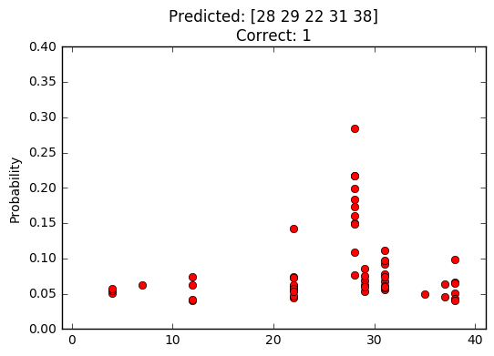

```
raw top_k results:

tf.nn.top_k(prediction, 5).values  [array([ 0.28507429,  0.06884204,  0.05951475,  0.05602842,  0.04012862], dtype=float32), array([ 0.18350342,  0.0985667 ,  0.07588598,  0.06097144,  0.04414776], dtype=float32), array([ 0.21701965,  0.09165222,  0.05466859,  0.05087453,  0.040593  ], dtype=float32…
tf.nn.top_k(prediction, 5).indices [array([28, 29, 22, 31, 38]), array([28, 38, 29, 31, 22]), array([28, 31, 22, 38, 12]), array([28, 31, 29, 35, 22]), array([28, 12, 37, 31, 22]), array([28, 22, 31, 29,  4]), array([28, 29, 31, 22,  4]), array([28, 31, 22, 38,  4]), array([28, 38, 22, 29, 31]), arr…
```

```python
def plot_top_k_probabilities(pred_cls, pred_prob, title):
    plt.plot(list(pred_cls), list(pred_prob), 'ro')
    x1,x2,y1,y2 = plt.axis()
    plt.axis((x1-1,x2+1,y1,y2+0.1))

    plt.ylabel('Probability')
    plt.title(title)

    plt.show()

print(values.shape)
print(values)

for i in range(len(values)):
    predicted_class = indices[i][np.argmax(values[i])]
    # NOTE: You'll need to refer to your newdata's correct labels here.
    # Swap out "newdata_labels" with your actual "true labels" array.
    correct_class = web_labels[i]
    plot_title = 'Predicted: {}\nCorrect: {}'.format(predicted_class, correct_class)

    plot_top_k_probabilities(indices[i], values[i], plot_title)

    print('raw top_k results:')
    print('')
    print('tf.nn.top_k(prediction, 5).values ', list(values[i]))
    print('tf.nn.top_k(prediction, 5).indices', list(indices[i]))


    print('')
    print('')
```